# Interpolation Lab

Jose Gomez

This document presents the results of the interpolation laboratory carried out in the Methods in Spatial Analysis class at the University of Salzburg.

## Introduction

According to Mitas & Mitasova (1999), the general formulation of the spatial interpolation problem can be defined as follows:

Given N values of a given phenomenon $Z_j$ for $j=0,1,2,...,N$ measured at discrete points $r_j=(x_j^{[1]},x_j^{[2]},...,x_j^{[d]})$ for $j=0,1,2,...,N$ N within a certain region of a d-dimensional space, find a d-variate continuous function $F(r)$ which passes through the given points, that means, fulfils the condition:

$F(r_j)=Z_j$ for $j=0,1,2,...,N$

Or in simpler words, find a function that is able to estimate unknown values at non-sampled positions, given a set of neighboring sampled values. In the following lines, different interpolation methods are tested over and compared.

## The data

The data used consist of a climatological dataset from 2008 provided for the Croatian Meteorological and Hydrological Service, it includes temperature and precipitation observations. Although the sampling is not regular, one of the focuses of the analysis will be the behavior of different techniques in the borders of the country. The variable to model is the median temperature for 28 September 2008.

```
##    Min. 1st Qu.  Median    Mean 3rd Qu.    Max.    NA's
##    8.33   16.83   17.96   17.77   19.20   23.87       4
```

[interactive chart not shown]

## Performance Assessment

As suggested in Tiengrod, P., & Wongseree, W. (2013) for verify the accuracy of the estimation data I used leave-one-out method in this experiment. Leave-one-out is used N-1 examples for training and the remaining example for testing for each experiment. I base my conclusions on the RMSE metrics.

## Inverse Distance Weighing (IDW)

This is one of the simplest and most readily available methods. It is based on an assumption that the value at an unsampled point can be approximated as a weighted average of values at points within a certain cut-off distance, or from a given number m of the closest points (typically 10 to 30). Weights are usually inversely proportional to a power of distance (Burrough 1986).

To select a proper power $p$ to be used in IDW method, graphical and statistical methods will be used. First we see the results of interpolations with different powers.

```
## tmap mode set to plotting
```

[output not shown]

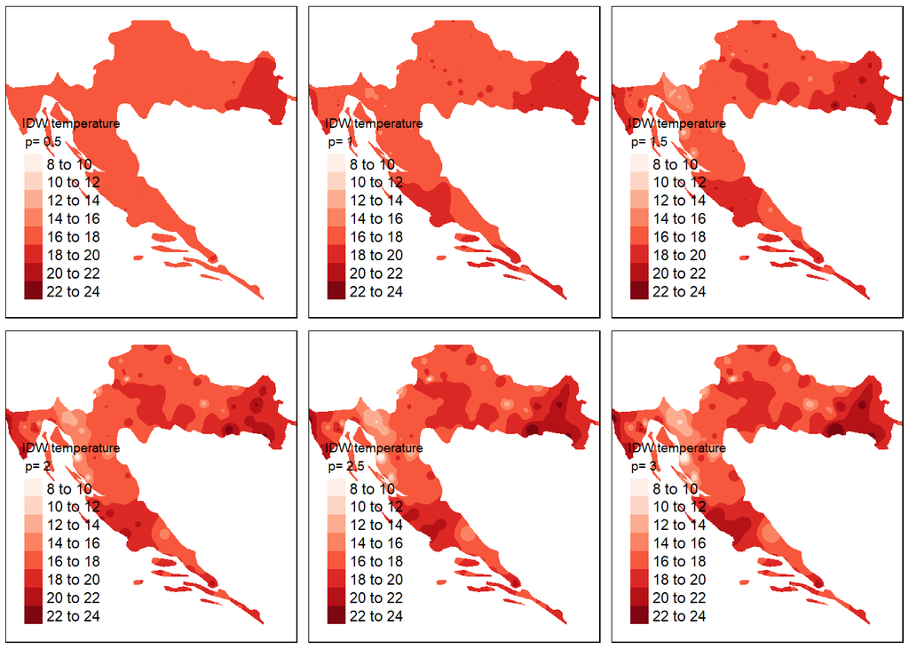

```
## tmap mode set to plotting
```

As we can see lower values of $p$ increase de smoothness of the interpolated surface, too ow values may lead to biased results where no information is retrieved from the neighboring samples. On the other hand high values of $p$ overtake the neighboring values and can produce false estimations. To asses the best power a cross-validation based on RSME is performed.

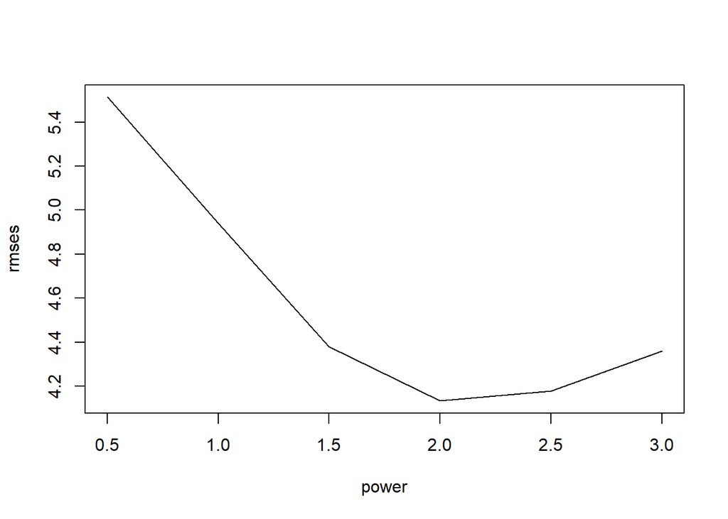

```r
plot(power, rmses, type="l")
```

With this estimation we can determine that 2 is the power that minimizes the total RMSE between original and interpolated values.

[interactive chart not shown]

```
## [1] 4.132835
```

[interactive chart not shown]

## Kriging

Kriging is based on a concept of random functions: the surface or volume is assumed to be one realization of a random function with a certain spatial covariance (Journel and Huijbregts 1978). For simplicity the background process of data preparation is not shown, after this we can assume the data is: isotropic, normal and has no trend. With this information we calculate an empirical variogram and then fit some semi-variogram models to it. The selected model is a classic variogram estimator with a Exponential model estimated by means of weighted least squares (no nested models are been considered).

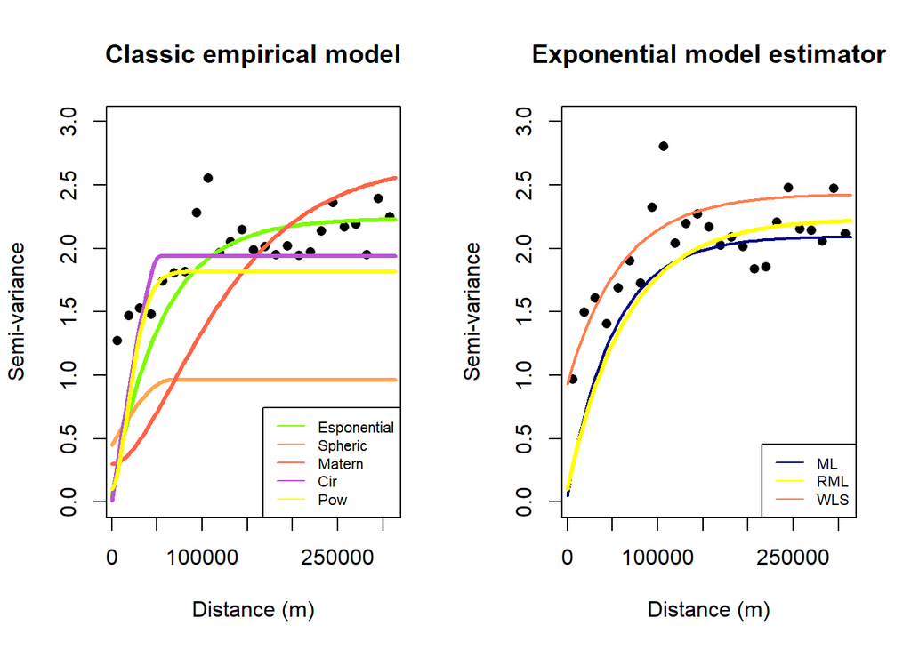

```
## tmap mode set to plotting
```

[figure not shown]

```
## tmap mode set to plotting
```

```r
risk.bins <-c(seq(8,24,2))
risk.pal <- colorBin( "Reds", bins=risk.bins,na.color = NA)


leaflet(data=croacia1) %>% addTiles()%>%addProviderTiles(providers$Stamen.Toner)%>%
  addCircleMarkers(lng = croacia1$lon, lat = croacia1$lat,color="black",radius = 1.5, stroke = FALSE, fillOpacity = 1)%>%
  addRasterImage(krig.map,colors = risk.pal) %>%addLegend(pal = risk.pal, values = values(krig.map),title = "Temp interpolation with IDW p=2")
```

[interactive chart not shown]

## Rreferences

Burrough, P. A. (1986). Principles of geographical information systems for land resources assessment. Clarendon.

Garnero, G., & Godone, D. (2013). Comparisons between different interpolation techniques. The International Archives of the Photogrammetry, Remote Sensing and Spatial Information Sciences, 5, W3.

Journel, A. G., & Huijbregts, C. J. (1978). Mining geostatistics. vol. 600 Academic press.

Mitas, L., & Mitasova, H. (1999). Spatial interpolation. Geographical information systems: principles, techniques, management and applications, 1(2).

Tiengrod, P., & Wongseree, W. (2013, September). A comparison of spatial interpolation methods for surface temperature in Thailand. In 2013 International Computer Science and Engineering Conference (ICSEC) (pp. 174-178). IEEE.